# Automotive Insights: Exploratory Data Analysis of Car Sales datasets using R

Hrithvik Jeevankumar Shetty

2023-04-05

Loading of Library

```r
library(tidyverse)
library(matlib)
```

## *Introduction*

The dataset Car_sales.csv consists of information regarding total sales of different car brand and their model. I chose this dataset out of all is because I am an automobile enthusiast since my childhood and loved everything about it. Here cars are grouped under its brands, price, engine capacity, power, etc. It is differentiated in the most efficient way according to buyer’s point of view so that he can get to know about all the information of different cars in one dataset. Buyer can compare according to their requirement like price of the car, engine capacity and make right decision about his purchase. It can answer some of the question such as which automaker has achieved the highest overall sales till date, when was the newest automobile model introduced, what is the estimated year-to-year resale value, comparison of the car's brand, price, and engine power.

#Data 1. Data source: Include the citation for your data & provide the link to the source. https://www.kaggle.com/datasets/gagandeep16/car-sales

2. Data collection: This data set was obtained from Analytixlabs in to predict future car sales and assist customers with their purchases.
3. Cases: The rows represent various attributes of the cars & its sales.
4. Variables
1. Manufacturer- Brand who manufactures the car.
2. Model- model from certain manufacturer of the car.
3. Sales_in_thousands- Number of cars sold.
4. __year_resale_value- Resale value of the car after a year.
5. Vehicle_type- Type of vehicle depending on its seating.
6. Price_in_thousands- Price of the car.
7. Engine_size- Capacity of the engine in the car.
8. Horsepower- Horsepower of the car engine.
9. Wheelbase- Length from front wheel to rare wheel.
10. Width- Width of the car.
5. Type of study: It is an observational dataset with data collected purely for the intention of prediction by Analytixhub.

# Data Quality

Adding Dataset

```r
TheDataset <- read.csv("C:\\Users\\user\\Downloads\\Car-sales.csv")
head(TheDataset)
```

```
##   Manufacturer   Model Sales_in_thousands X__year_resale_value Vehicle_type
## 1        Acura Integra             16.919               16.360    Passenger
## 2        Acura      TL             39.384               19.875    Passenger
## 3        Acura      CL             14.114               18.225    Passenger
## 4        Acura      RL              8.588               29.725    Passenger
## 5         Audi      A4             20.397               22.255    Passenger
## 6         Audi      A6             18.780               23.555    Passenger
##   Price_in_thousands Engine_size Horsepower Wheelbase Width Length Curb_weight
## 1              21.50         1.8        140     101.2  67.3  172.4       2.639
## 2              28.40         3.2        225     108.1  70.3  192.9       3.517
## 3                 NA         3.2        225     106.9  70.6  192.0       3.470
## 4              42.00         3.5        210     114.6  71.4  196.6       3.850
## 5              23.99         1.8        150     102.6  68.2  178.0       2.998
## 6              33.95         2.8        200     108.7  76.1  192.0       3.561
##   Fuel_capacity Fuel_efficiency Latest_Launch Power_perf_factor
## 1          13.2              28      2/2/2012          58.28015
## 2          17.2              25      6/3/2011          91.37078
## 3          17.2              26      1/4/2012                NA
## 4          18.0              22     3/10/2011          91.38978
## 5          16.4              27     10/8/2011          62.77764
## 6          18.5              22      8/9/2011          84.56511
```

```r
(dim(TheDataset))
```

```
## [1] 157  16
```

The dataset has 16 columns & 157 observations

For finding missing value

```r
sum(is.na(TheDataset))
```

```
## [1] 51
```

```r
colSums(is.na(TheDataset))
```

```
##         Manufacturer                Model   Sales_in_thousands
##                    0                    0                    0
## X__year_resale_value         Vehicle_type   Price_in_thousands
##                   36                    0                    2
##          Engine_size           Horsepower            Wheelbase
##                    1                    1                    1
##                Width               Length          Curb_weight
##                    1                    1                    2
##        Fuel_capacity      Fuel_efficiency        Latest_Launch
##                    1                    3                    0
##    Power_perf_factor
##                    2
```

For finding duplicates

```r
sum(duplicated(TheDataset))
```

```
## [1] 0
```

There are zero duplicate values in this Dataset

# Data Cleaning

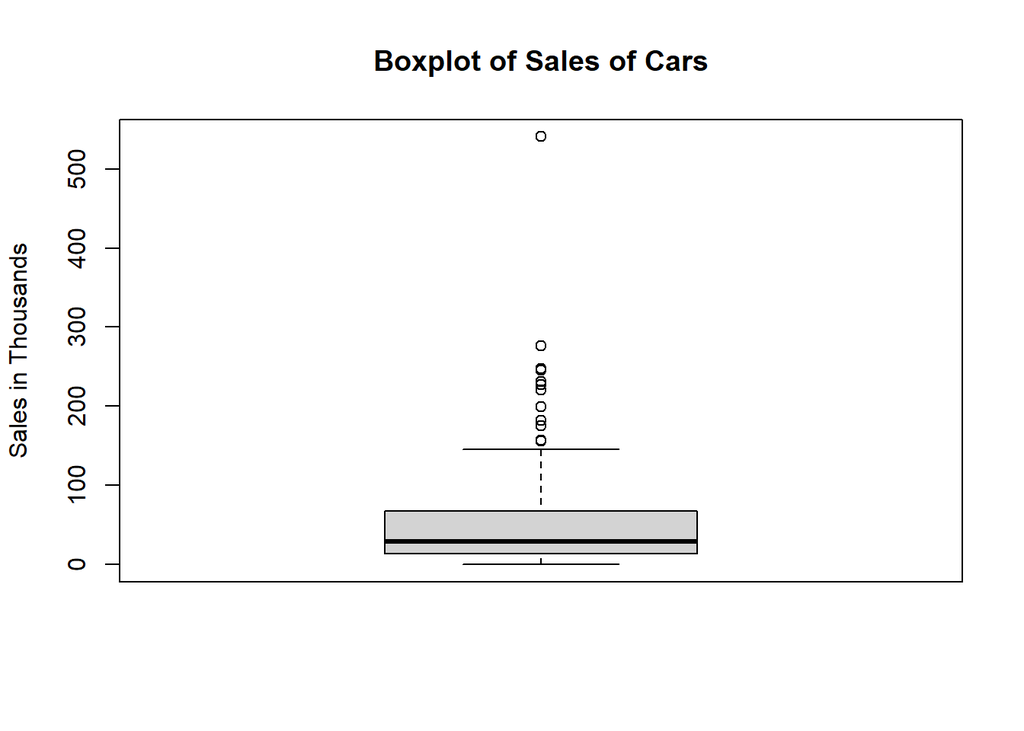

```r
Sales_Outliers <- boxplot(TheDataset$Sales_in_thousands, ylab = "Sales in Thousands",main = "Boxplot of Sales of Cars")$out
```

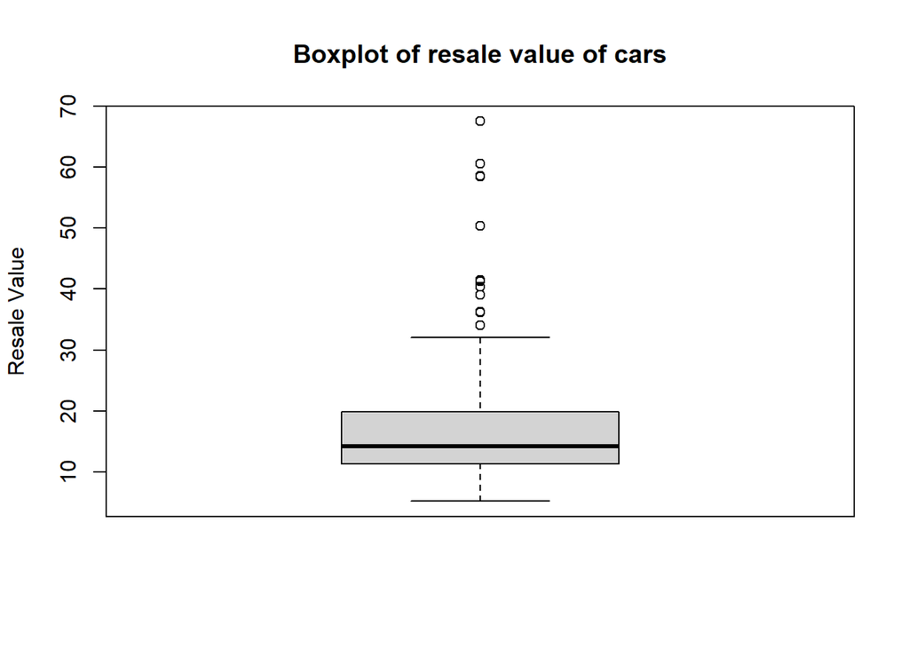

```r
resale_outliers <- boxplot(TheDataset$X__year_resale_value, ylab = "Resale Value",main = "Boxplot of resale value of cars")$out
```

```r
Data <- TheDataset
Data <- Data[-which(Data$Sales_in_thousands %in% Sales_Outliers),]
Data <- Data[-which(Data$X__year_resale_vallue %in% resale_outliers),]
```

# Data Visualization

Comparing average price for different automobile manufacturers.

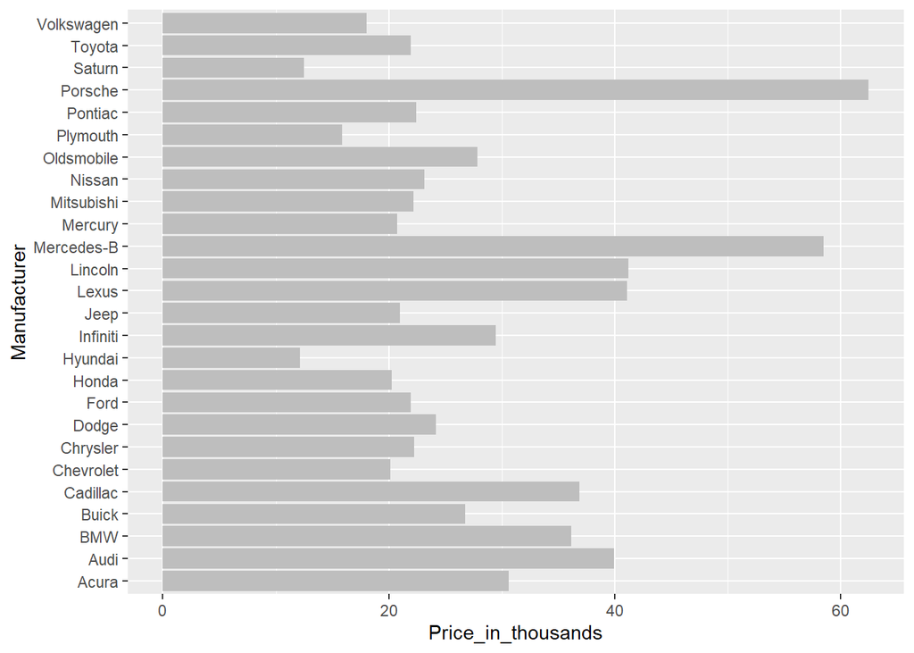

```r
TheData <- na.omit(TheDataset)
ggplot(TheData,aes(Manufacturer,Price_in_thousands))+
geom_bar(stat = "summary", fun = "mean", fill = "Grey")+coord_flip()
```

We can say from the above graph Porsche and Mercedes Benz are the most expensive while Hyundai and Saturn being the cheapest

Comparing sales of cars and passengers.

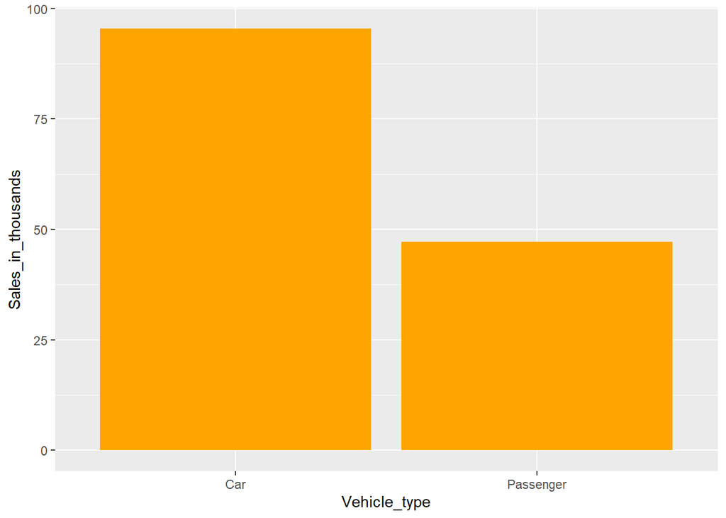

```r
ggplot(TheData,aes(Sales_in_thousands, Vehicle_type)) +
geom_bar(stat = "summary",fun = "mean", fill = "ORANGE")+ coord_flip()
```

Comparing horsepower with fuel efficiency for all Automobile manufacturers.

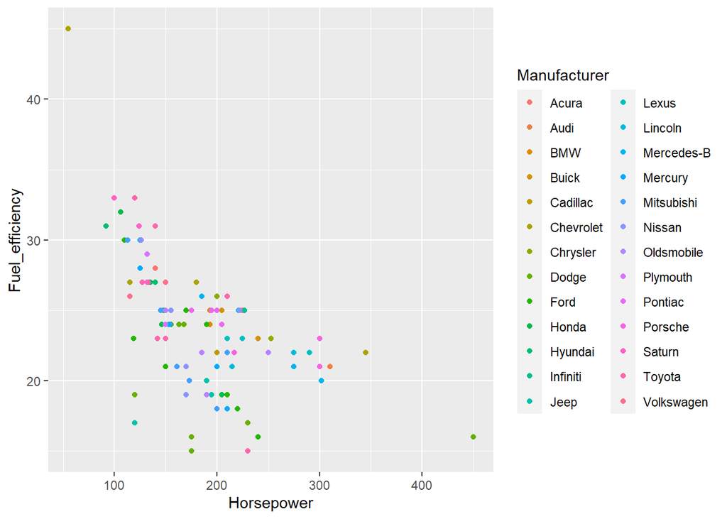

```r
ggplot(TheData,aes(Horsepower,Fuel_efficiency, color= Manufacturer))  +
geom_point()
```

We can observe from the graph that as the horsepower of car increases the fuel efficiency decreases.

Determining fuel efficiency for different Automobile manufacturers.

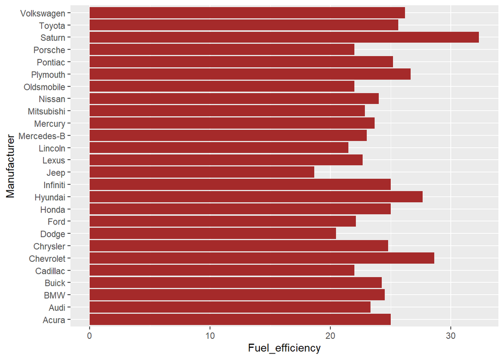

```r
ggplot(TheData,aes(Manufacturer,Fuel_efficiency)) +
geom_bar(position = "dodge", stat = "summary",fun = "mean", fill = "BROWN") +
coord_flip()
```

We can observe from the graph that Saturn and Chevrolet has highest fuel efficiency compared to other car manufacturer while Jeep being the lowest efficiency.

### **Questions for next stage**

1. Is the sales of car more of high fuel efficient cars?
2. Is cost associated with the engine size
3. Is fuel capacity associated with the curb weight of the car?

# HYPOTHESIS 1

In EDA, I evaluated average fuel efficiency of all the car manufacturers. In this, I want to test if the average fuel efficiency of all the vehicles is 25 miles per gallon or less.

H0 = The mean of fuel efficiency was proven to be 25 H1 = Mean is less than 25

```r
res <- t.test(TheData$Fuel_efficiency, mu = 25)
res
```

```
##
##  One Sample t-test
##
## data:  TheData$Fuel_efficiency
## t = -2.162, df = 116, p-value = 0.03267
## alternative hypothesis: true mean is not equal to 25
## 95 percent confidence interval:
##  23.31316 24.92616
## sample estimates:
## mean of x
##  24.11966
```

The p-value t-test is less than the significance level of 0.05. In conclusion, there is a difference between the mean. Hence we reject the NULL Hypothesis Ho, i.e µ = 25.

# HYPOTHESIS 2

As the horsepower of the car engine & its fuel efficiency are correlated, I’m trying to figure out whether their variance matches up for the vast variety of car models.

H0: σ1 = σ2 (the variances are equal)

H1: σ1 ≠ σ2 (the variances are not equal)

```r
var.test(TheData$Horsepower,TheData$Fuel_efficiency)
```

```
##
##  F test to compare two variances
##
## data:  TheData$Horsepower and TheData$Fuel_efficiency
## F = 176.96, num df = 116, denom df = 116, p-value < 2.2e-16
## alternative hypothesis: true ratio of variances is not equal to 1
## 95 percent confidence interval:
##  122.7560 255.1114
## sample estimates:
## ratio of variances
##           176.9645
```

It is obvious that because the P value is significantly below 0.05, the null hypothesis can be rejected. As a result, the alternative hypothesis is correct. Additionally, it is noticed that difference between 2 samples for 95% confidence interval is very large. The two variances therefore cannot be equivalent to one another.

## Principal Component Analysis

```r
pca_data <- TheData[c(1:17),c(3, 4, 6, 7, 8, 9, 10, 11, 12, 14, 16)]
head(pca_data)
```

```
##   Sales_in_thousands X__year_resale_value Price_in_thousands Engine_size
## 1             16.919               16.360              21.50         1.8
## 2             39.384               19.875              28.40         3.2
## 4              8.588               29.725              42.00         3.5
## 5             20.397               22.255              23.99         1.8
## 6             18.780               23.555              33.95         2.8
## 7              1.380               39.000              62.00         4.2
##   Horsepower Wheelbase Width Length Curb_weight Fuel_efficiency
## 1        140     101.2  67.3  172.4       2.639              28
## 2        225     108.1  70.3  192.9       3.517              25
## 4        210     114.6  71.4  196.6       3.850              22
## 5        150     102.6  68.2  178.0       2.998              27
## 6        200     108.7  76.1  192.0       3.561              22
## 7        310     113.0  74.0  198.2       3.902              21
##   Power_perf_factor
## 1          58.28015
## 2          91.37078
## 4          91.38978
## 5          62.77764
## 6          84.56511
## 7         134.65686
```

Eliminated columns that are not of interest.

```r
scaled_pca <- scale(pca_data)
pca_cor <- cor(scaled_pca)
is_orthogonal_matrix(pca_cor)
```

```
## [1] FALSE
```

Generated correlation matrix for PCA.

```r
eigen_pca = eigen(pca_cor)
eigen_value <- eigen_pca$values
eigen_vectors <- eigen_pca$vectors
```

The eigen values and eigen vectors of the correlation matrix are obtained.

```r
variance_pca <- eigen_value / sum(eigen_value)
cumsum(variance_pca)
```

```
##  [1] 0.6916401 0.8675291 0.9095907 0.9469400 0.9681197 0.9873364 0.9926799
##  [8] 0.9965007 0.9990179 1.0000000 1.0000000
```

The first two principal components are sufficient for analysis as it explains around 86% variability in the data.

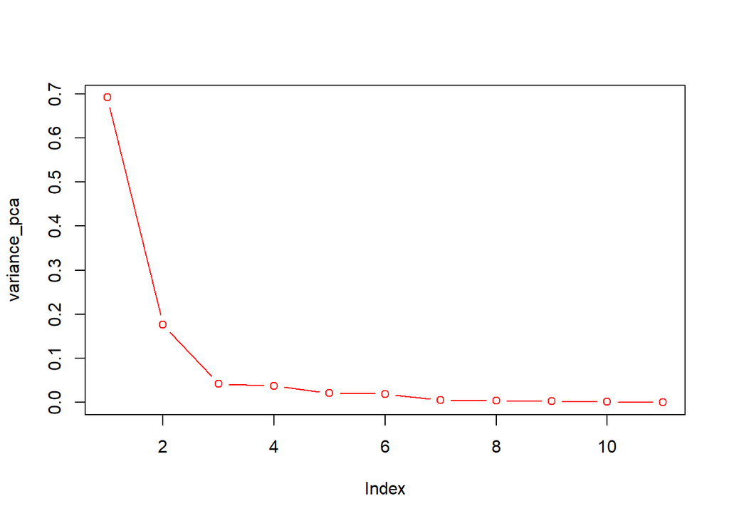

```r
plot(variance_pca,type = "b",col="red")
```

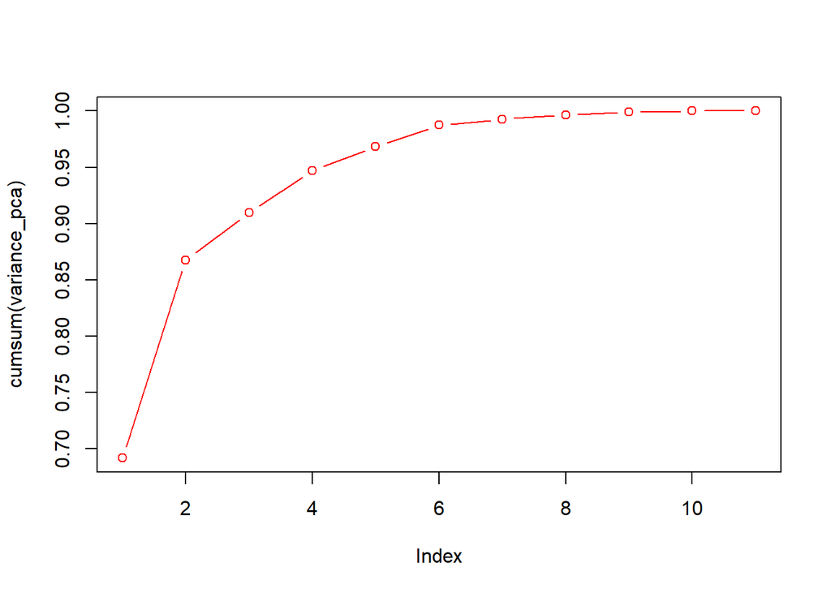

```r
plot(cumsum(variance_pca),type = "b",col="red")
```

```r
computed = eigen_vectors[,1:2]
colnames(computed) = c("pc1", "pc2")
row.names(computed) = colnames(pca_data)
computed
```

```
##                             pc1          pc2
## Sales_in_thousands    0.1687070  0.546833857
## X__year_resale_value -0.2149825 -0.527012309
## Price_in_thousands   -0.3109547 -0.324140646
## Engine_size          -0.3205674  0.262738093
## Horsepower           -0.3405950 -0.026825922
## Wheelbase            -0.3014049  0.177505565
## Width                -0.2959573  0.231253348
## Length               -0.2931460  0.388335812
## Curb_weight          -0.3473876  0.073031241
## Fuel_efficiency       0.3250451  0.001317556
## Power_perf_factor    -0.3451906 -0.085359986
```

The first principal component (PC1) is inversely linked with price and residual value, indicating that as a car’s size, weight, horsepower, and other characteristics decline, so too do its price and residual value.

## Conclusion

We have analysed the data set to give insight for car buyers on important considerations. It is important to take into account variables like pricing, horsepower, and fuel efficiency.

Hyundai, Saturn, and Chevrolet vehicles are more affordable and have superior fuel efficiency than those from other companies.Given the exorbitant cost of premium brands, there aren’t many people buying expensive cars. Additionally, we see an inverse relationship between horsepower and fuel economy, meaning that as horsepower rises, fuel efficiency falls.